# Analysis about StackOverflow

##### Name: Zhiqi Fu

[figure not shown]

## Introduction

I always use StackOverflow in my computer science courses. Whenever I have questions, I will search on the internet and most time, I could find the answers on StackOverflow. It is a really useful website for me. However, for now, most of my CS courses are about Java. I wondered if that website also popular in other computing languages. I used the dataset posts_questions to explore more about StackOverflow. The dataset collected questions posted on the StackOverflow and contained information like posted_date, tags, view_count...

Here are some questions that I want to answer:

1. What computing language had been asked most frequently on Stackoverflow?
   - Which computing languages have the most questions number on StackOverflow?
   - How many view_counts are there for each computing languages?
1. What is the development of Stackoverflow? Does it become more and more popular and well-known?

### Related links

- [Google BigQuery](https://cloud.google.com/bigquery/what-is-bigquery)
- BigQuery [SQL reference](https://cloud.google.com/bigquery/query-reference)
- Python [Pandas](http://pandas.pydata.org/) for data analysis
- Python [matplotlib](http://matplotlib.org/) for data visualization

```python
import google.datalab.bigquery as bq
import matplotlib.pyplot as plot
import numpy as np
import pandas as pd
import datetime as dt
import seaborn as sns
```

## Understanding the dataset

We're going to use the StackOverflow posts_questions data. It contains id, title, body, answer count, comment count, creation date, favorite count, tags, view count, etc. We first have an overview of the dataset(name represents for the variables the dataset has and its type)

```python
%%bq tables describe --name "bigquery-public-data.stackoverflow.posts_questions"
```

We then use the row count to find out how large this dataset is. (How many rows are there)

```python
table = bq.Table('bigquery-public-data.stackoverflow.posts_questions')
table.metadata.rows
```

```
16389567
```

The dataset is quite large with more than 16 millions of data.

Since we only want to focus on our question, we need to sample data and look at the columns we need.

```python
bq.Query.from_table(table).execute(sampling=bq.Sampling.default(
    fields=['answer_count',
            'favorite_count',
            'score',
            'tags',
            'view_count'])).result()
```

| answer_count | favorite_count | score | tags | view_count |
| --- | --- | --- | --- | --- |
| 2 |  | 0 | android\|json | 1556 |
| 0 |  | 0 | javascript\|node.js\|mongodb\|mongoose | 135 |
| 0 |  | 1 | php\|laravel\|travis-ci\|laravel-dusk | 209 |
| 1 |  | 1 | jax-ws\|webservice-client | 309 |
| 2 |  | 2 | java-ee\|glassfish\|ejb | 705 |

(rows: 5, time: 0.2s, cached, job: job_bBIm3sIo37Cypz89DAe1BvdlrGk4)

## Querying the Data

First of all, my questions are only related to a few columns, thus I do not need all of them. I need to select the columns I need from the dataset.

```python
%%bq query --name sub
SELECT creation_date, favorite_count, tags, view_count
FROM `bigquery-public-data.stackoverflow.posts_questions`
```

Then, I want to have a preview of the columns I selected.

```python
query = sub.execute()
query.result()
```

| creation_date | favorite_count | tags | view_count |
| --- | --- | --- | --- |
| 2010-01-11 00:00:30.287000 | 17 | c#\|registry\|64bit\|wow64 | 58764 |
| 2011-01-24 18:18:16.817000 | 8 | android\|image\|click\|clickable-image | 42794 |
| 2015-09-07 12:54:43.890000 | 6 | ios\|arrays\|swift | 13689 |
| 2009-11-25 14:27:33.047000 | 9 | f#\|functional-programming\|while-loop\|tail-recursion | 3511 |
| 2013-02-28 09:26:56.980000 | 5 | git\|bitbucket | 28671 |
| 2011-06-05 11:59:57.273000 | 46 | linux\|elf | 131762 |
| 2012-12-14 15:10:25.500000 | 9 | c++\|gcc\|pgo\|lto | 17346 |
| 2011-11-08 22:47:46.577000 | 9 | macos\|cocoa | 7596 |
| 2014-01-30 14:44:49.303000 | 5 | git\|github\|git-branch\|git-svn\|git-tag | 12925 |
| 2009-10-24 19:27:57.797000 | 11 | performance\|optimization\|haskell\|lazy-evaluation\|ghc | 2878 |
| 2012-08-29 17:02:23.997000 | 49 | c++\|enums | 305938 |
| 2008-11-01 23:02:36.767000 | 43 | python\|exception\|arguments | 133287 |
| 2011-03-25 20:08:55.047000 | 8 | html\|eclipse\|eclipse-plugin | 72765 |
| 2012-02-03 20:18:40.837000 | 5 | emacs\|org-mode\|bibtex\|biblatex | 1669 |
| 2010-03-08 22:19:21.963000 | 14 | c#\|.net\|reflection\|logging\|parameters | 29563 |
| 2016-07-18 08:34:51.437000 | 8 | algorithm\|sorting\|dynamic-programming\|greedy | 314 |
| 2010-02-10 07:22:20.620000 | 10 | security\|sha1 | 72170 |
| 2011-01-11 11:12:48.283000 | 12 | android\|imagebutton\|aspect-ratio | 33693 |
| 2009-11-24 08:13:24.233000 | 21 | image\|layout\|latex\|figure | 112612 |
| 2009-12-15 04:16:00.317000 | 7 | android\|icons | 13776 |
| 2008-10-20 21:30:10.607000 | 120 | asp.net-mvc\|forms\|checkbox | 229711 |
| 2011-09-28 10:45:02.153000 | 6 | javascript\|json\|node.js\|serverside-javascript\|circular-reference | 5835 |
| 2010-11-26 20:22:37.077000 | 5 | emacs\|lisp\|paredit | 3685 |
| 2009-08-25 20:14:13.757000 | 11 | php\|regex\|preg-match | 59856 |
| 2011-09-05 10:46:44.650000 | 7 | jquery\|if-statement\|switch-statement\|window-resize\|css | 40607 |

(rows: 16389567, time: 19.1s, 734MB processed, job: job_uU4n_PrSPoUl11XZwtdvKtnny-bl)

Try: I tried to use SQL to find how many tags include each computing languages, for example, Java. However, I found out the output like what showed below is not easy to see. Thus, I want to convert to data frame, so I could have a direct and better result for my questions

```python
%%bq query
SELECT COUNT(*)
FROM `bigquery-public-data.stackoverflow.posts_questions`
WHERE tags LIKE '%java%'
```

| f0_ |
| --- |
| 3171337 |

(rows: 1, time: 0.2s, cached, job: job_aA36P8DVyhBYIcU_fffb5-gxYUbp)

## Converting to data frame

```python
%%bq query -n requests
SELECT creation_date, tags, view_count
FROM `bigquery-public-data.stackoverflow.posts_questions`
```

```python
%%bq sample --count 5 --query requests
```

| creation_date | tags | view_count |
| --- | --- | --- |
| 2014-07-25 08:21:42.593000 | javascript\|angularjs\|angularjs-filter | 224 |
| 2009-07-07 15:46:47.957000 | java\|generics\|static-methods | 6900 |
| 2017-10-27 19:23:37.743000 | android\|android-fragments\|android-activity\|android-viewpager\|fragment | 907 |
| 2012-05-21 18:04:10.237000 | java\|uml\|code-generation\|modeling | 418 |
| 2017-07-08 03:23:35.747000 | javascript\|node.js\|express\|cors\|fetch-api | 81 |

(rows: 5, time: 1.0s, 705MB processed, job: job_nG6qUtre8hHfY1qBNz8ihz55VVVR)

```python
df = requests.execute(output_options=bq.QueryOutput.dataframe()).result()
len(df)
```

```
16389567
```

## Analyzing the data

### Question 1:

We look at the column 'tags' and want to see how many times each language appear in the tag. If that language is in the tag, that means the question is about that computing languages. Here, I focused on a few main computing languages that I have learned: Java, Python, SQL, Matlab.

```python
java = df[df['tags'].str.contains("java", na=False)]
print("the number of posts related to java is: " + str(len(java.index)))
python = df[df['tags'].str.contains("python", na=False)]
print("the number of posts related to python is: " + str(len(python.index)))
sql = df[df['tags'].str.contains("sql", na=False)]
print("the number of posts related to sql is: " + str(len(sql.index)))
matlab = df[df['tags'].str.contains("matlab", na=False)]
print("the number of posts related to matlab is: " + str(len(matlab.index)))
```

```
the number of posts related to java is: 3171337
the number of posts related to python is: 1102925
the number of posts related to sql is: 1281126
the number of posts related to matlab is: 80382
```

From the result, I learned that Java has the most posted questions among those four computing languages. Python and SQL have less, and Matlab has least questions posted. However, the number of questions posted did not represent a lot. I also want to see the average view counts of each question posted for each computing language. Therefore, I count the total view count and divide it by the number of questions posted to get the average.

```python
java = df[df['tags'].str.contains("java", na=False)]
java_sum = java['view_count'].sum()
java_count = java['view_count'].count()
java_ave = java_sum/java_count
print("the average java view count is:" + str(java_ave))

python_sum = python['view_count'].sum()
python_count = python['view_count'].count()
python_ave = python_sum/python_count
print("the average python view count is:" + str(python_ave))

sql_sum = sql['view_count'].sum()
sql_count = sql['view_count'].count()
sql_ave = sql_sum/sql_count
print("the average sql view count is:" + str(sql_ave))

matlab_sum = matlab['view_count'].sum()
matlab_count = matlab['view_count'].count()
matlab_ave = matlab_sum/matlab_count
print("the average matlab view count is:" + str(matlab_ave))
```

```
the average java view count is:2291
the average python view count is:2108
the average sql view count is:2155
the average matlab view count is:1451
```

The result is almost the same as the number of questions posted. Java has the most, Python and SQL have less and Matlab has least average view count. However, the difference between Java, Python, and SQL is not a lot.

From those two results, I could know that Java is a popular computing language that is discussed a lot on StackOverflow. Python and SQL are also popular and I could use StackOverflow to find the answers I want. However, there is not lots of information on StackOverflow for Matlab. It is a quite genuine result because I always found a great answer on StackOverflow, while I recalled when I learned Matlab, I rarely use StackOverflow. Instead, Mathworks is the website I could found the best solution.

### Question 2:

Since I want to find the development of Stackoverflow these years, I do not need all the creation date, instead, I only need creation year. Therefore, I create a new column and store the creation year in that column.

```python
df['creation_date'] = pd.to_datetime(df['creation_date'])
df['year']= df['creation_date'].dt.year
df
```

|  | creation_date | tags | view_count | year |
| --- | --- | --- | --- | --- |
| 0 | 2018-05-13 16:28:46.230 | python\|opencv\|image-loading | 88 | 2018 |
| 1 | 2018-07-03 18:10:48.180 | ruby-on-rails\|monkeypatching | 31 | 2018 |
| 2 | 2017-05-26 22:50:30.357 | python\|scikit-learn | 532 | 2017 |
| 3 | 2013-09-19 10:34:18.643 | java\|android\|mysql\|database\|sqlite | 1474 | 2013 |
| 4 | 2017-10-27 10:23:19.273 | angular | 124 | 2017 |
| 5 | 2015-12-18 08:53:31.307 | tfs\|wiql | 309 | 2015 |
| 6 | 2011-07-20 17:44:17.783 | iphone\|uibutton | 3806 | 2011 |
| 7 | 2016-08-12 09:32:55.523 | php\|google-maps\|google-maps-api-3\|google-dista... | 1153 | 2016 |
| 8 | 2015-07-15 10:38:40.937 | javascript\|jquery\|html | 2194 | 2015 |
| 9 | 2013-02-22 09:44:34.837 | android\|eclipse\|avd | 11016 | 2013 |
| 10 | 2017-05-24 09:54:50.477 | animation\|use-case\|svg.js | 39 | 2017 |
| 11 | 2013-07-08 07:48:03.520 | r\|ggplot2 | 18074 | 2013 |
| 12 | 2018-06-06 14:23:57.520 | react-native | 124 | 2018 |
| 13 | 2018-06-23 05:09:33.530 | python\|web-scraping\|export-to-csv | 40 | 2018 |
| 14 | 2011-06-23 05:57:54.943 | javascript\|events\|google-maps | 101 | 2011 |
| 15 | 2014-07-21 18:11:54.703 | ios\|objective-c\|uibutton\|uiimage | 921 | 2014 |
| 16 | 2012-06-04 08:27:44.417 | android\|android-source | 1320 | 2012 |
| 17 | 2018-08-15 05:53:00.553 | python\|user-interface\|tkinter | 31 | 2018 |
| 18 | 2011-07-27 06:49:15.140 | qt\|qt4 | 346 | 2011 |
| 19 | 2017-03-03 06:50:13.697 | wordpress\|forms\|builder\|infusionsoft | 123 | 2017 |
| 20 | 2011-04-11 07:08:46.063 | c#\|asp.net\|facebook\|facebook-c#-sdk | 1080 | 2011 |
| 21 | 2018-01-10 15:20:43.623 | java\|android\|google-maps\|bottom-sheet | 155 | 2018 |
| 22 | 2013-03-28 16:39:46.550 | c++\|fortran\|binaryfiles | 1428 | 2013 |
| 23 | 2016-07-04 04:01:51.823 | javascript\|angularjs\|ionic-framework | 339 | 2016 |
| 24 | 2018-08-23 19:07:14.750 | ssl\|apache-kafka\|acl\|kafka-consumer-api | 11 | 2018 |
| 25 | 2013-03-14 08:11:27.990 | c++\|templates\|c++11\|compile-time\|typetraits | 4121 | 2013 |
| 26 | 2017-11-10 12:07:23.980 | ios\|swift\|scroll\|collectionview | 1041 | 2017 |
| 27 | 2017-05-02 07:41:04.957 | xslt-2.0 | 159 | 2017 |
| 28 | 2016-10-10 13:03:27.257 | javascript\|node.js | 703 | 2016 |
| 29 | 2015-12-08 17:47:21.807 | php\|html\|image\|background\|slider | 1324 | 2015 |
| ... | ... | ... | ... | ... |
| 16389537 | 2016-02-18 05:20:20.207 | javascript\|jquery | 42 | 2016 |
| 16389538 | 2015-06-18 12:48:15.757 | javascript\|jquery | 42 | 2015 |
| 16389539 | 2016-08-05 07:52:55.773 | javascript\|jquery | 42 | 2016 |
| 16389540 | 2016-05-05 02:31:26.300 | javascript\|jquery | 42 | 2016 |
| 16389541 | 2016-12-09 11:11:24.307 | javascript\|jquery | 42 | 2016 |
| 16389542 | 2015-12-24 22:39:36.347 | javascript\|jquery | 42 | 2015 |
| 16389543 | 2014-02-20 03:15:43.463 | javascript\|jquery | 42 | 2014 |
| 16389544 | 2016-01-12 19:49:26.310 | javascript\|jquery | 42 | 2016 |
| 16389545 | 2017-10-03 11:11:45.293 | javascript\|jquery | 42 | 2017 |
| 16389546 | 2014-07-21 12:34:26.780 | javascript\|jquery | 42 | 2014 |
| 16389547 | 2017-11-17 00:24:39.347 | javascript\|jquery | 42 | 2017 |
| 16389548 | 2016-11-16 15:00:22.053 | javascript\|jquery | 42 | 2016 |
| 16389549 | 2017-05-19 10:32:14.070 | javascript\|jquery | 42 | 2017 |
| 16389550 | 2018-07-19 16:29:04.347 | javascript\|jquery | 42 | 2018 |
| 16389551 | 2018-08-31 14:27:05.553 | javascript\|jquery | 42 | 2018 |
| 16389552 | 2018-08-02 06:39:30.420 | javascript\|jquery | 42 | 2018 |
| 16389553 | 2017-11-22 07:28:52.317 | javascript\|jquery | 42 | 2017 |
| 16389554 | 2013-01-06 23:15:14.483 | javascript\|jquery | 42 | 2013 |
| 16389555 | 2017-01-25 16:05:51.653 | javascript\|jquery | 42 | 2017 |
| 16389556 | 2016-10-19 00:25:35.623 | javascript\|jquery | 42 | 2016 |
| 16389557 | 2016-01-06 12:31:44.543 | javascript\|jquery | 42 | 2016 |
| 16389558 | 2015-01-07 14:16:45.650 | javascript\|jquery | 42 | 2015 |
| 16389559 | 2013-10-15 00:41:02.987 | javascript\|jquery | 42 | 2013 |
| 16389560 | 2018-01-12 09:32:48.273 | javascript\|jquery | 42 | 2018 |
| 16389561 | 2014-04-05 02:31:50.583 | javascript\|jquery | 42 | 2014 |
| 16389562 | 2012-09-24 01:18:12.667 | javascript\|jquery | 42 | 2012 |
| 16389563 | 2018-08-09 15:20:31.277 | javascript\|jquery | 42 | 2018 |
| 16389564 | 2015-10-06 14:35:31.797 | javascript\|jquery | 42 | 2015 |
| 16389565 | 2015-06-11 21:57:21.997 | javascript\|jquery | 42 | 2015 |
| 16389566 | 2016-03-21 09:06:32.630 | javascript\|jquery | 42 | 2016 |

16389567 rows × 4 columns

I grouped by year and want to see how many questions posted each year.

```python
eachyear = df.groupby("year")
size = eachyear.size()
size
```

```
year
2008      58326
2009     343716
2010     694102
2011    1200071
2012    1644705
2013    2059303
2014    2163299
2015    2217754
2016    2223720
2017    2237847
2018    1546724
dtype: int64
```

```
Text(0.5,0,u'Year')
```

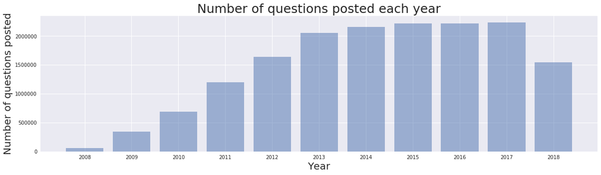

```python
performance = size
objects = ('2008', '2009','2010','2011', '2012','2013','2014','2015','2016','2017','2018')
plot.figure(figsize=(20,5))
plot.bar(objects, performance, align='center', alpha=0.5)
plot.title('Number of questions posted each year',fontsize=25)
plot.ylabel('Number of questions posted',fontsize=20)
plot.xlabel('Year',fontsize=20)
```

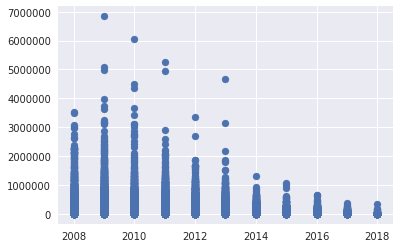

```python
plot.scatter(df.year, df.view_count)
plot.figure(figsize=(50,50))
```

The result is quite interesting that although the number of question increased almost every year, the number of popularity actually decreased. There are some really popular posts from 2009 to 2013 and points are gathered together in 2017 and 2018 which means, all the posts are not viewed a lot recently. This phenomenon is a little bit wired. I thought both the number of questions posted and the amount of really popular posts should increase year by year since computer science becomes more and more popular, lots of people start to learn computing languages and there would have more discussions about those on StackOverflow.

## Conclusion:

[figure not shown]

## Limitation:

1. Since all the computing languages are showed in tags, instead of individually, I used "contains" method to find how many times those languages appeared. However, the result I found for Java will include both java and javascript, since javascript also contains "java". Also, I could apply this method to r language, since lots of words also contain "r". Another method, like "split" command could be used to solve this problem.
1. The graph I drew for the view count of StackOverflow each year showed the outliers(high view count) clearly, but since all the lower view counts are gathered together, I could not have too much information for that part. Also, I could only find out the number of popular posts decreased, but I failed to think of a reason to explain that situation. This may be because from 2009 to 2013, computer science is still a new area and people did not have clear and absolutely correct answers to some basic questions, so they discussed a lot on StackOverflow. However, recently, people do not need to ask on StackOverflow for some basic questions. Most questions that posted on the StackOverflow are useful to a limited group of people. This is just my speculation and more information is needed to find out the reason.

### API：

I export the data frame I used as "submission.csv" and store both the excel and my project to my "lydiaproject" bucket. I changed the permission to allusers, so others could access to it.

```python
df.to_csv("submission.csv", encoding='utf-8', index=False)
```

```python
!pip install --upgrade google-cloud-storage
```

```
    100% |████████████████████████████████| 61kB 2.3MB/s ta 0:00:011
```

```python
# Imports the Google Cloud client library
from google.cloud import storage
# Put the excel(submission.csv) to my bucket(lydiaproject)
client = storage.Client()
bucket = client.get_bucket('lydiaproject')
blob = bucket.blob('submission.csv')
blob.upload_from_filename('submission.csv')
blob.make_public()
```